# R_Activity_11

Dahee Ahn

2024-11-21

```r
rm(list=ls())
library(permute)
library(vegan)
library(reshape2)
library(lattice)
library(dplyr)
```

## 1. We will use another open source data set from the NSF Harvard Forest Long-term Ecological Research (LTER) site. These data are spiders collected in the Hemlock Removal Experiment. Remember, this experiment includes four treatments (Hemlock girdled, Hemlock logged, Hemlock control, and Hardwood control) each replicated across two (n = 2) 90 x 90 m plots. Load the HarvardForest_spiders data into R. We will characterize spider communities among these four treatments. Load the HarvardForest_HerbLayer data into R. We will also assess the relationship among spiders and under story plants.

```r
spiders <- read.csv(file="C:/Users/chemk/Desktop/Classes/ENT6707_DataAnalysis/week14/Data/HarvardForest_spiders.csv", header=T, na.strings=c("", ".", "NA"))
herb <- read.csv(file="C:/Users/chemk/Desktop/Classes/ENT6707_DataAnalysis/week14/Data/HarvardForest_HerbLayer.csv", header=T, na.strings=c("", ".", "NA"))
```

```r
View(spiders)
str(spiders)
```

```
## 'data.frame':    1852 obs. of  13 variables:
##  $ start.date     : chr  "7/18/2008" "5/19/2008" "9/22/2008" "7/18/2008" ...
##  $ end.date       : chr  "7/28/2008" "5/29/2008" "10/2/2008" "7/28/2008" ...
##  $ block          : chr  "Valley" "Valley" "Valley" "Valley" ...
##  $ treatment      : chr  "Girdled" "Girdled" "Girdled" "Girdled" ...
##  $ plot           : int  1 1 1 1 1 1 1 1 1 1 ...
##  $ replicate      : int  5 3 1 5 5 5 1 5 1 5 ...
##  $ sampling.method: chr  "Litter_sifting" "Litter_sifting" "Litter_sifting" "Litter_sifting" ...
##  $ family         : chr  "LINYPHIIDAE" "SALTICIDAE" "LINYPHIIDAE" "AMAUROBIIDAE" ...
##  $ genus          : chr  "Ceraticelus" "immSalt" "immLiny" "immAmau" ...
##  $ species        : chr  "laetabilis" "sp." "sp." "sp." ...
##  $ males          : int  0 0 0 0 0 1 0 1 0 0 ...
##  $ females        : int  2 0 0 0 0 0 0 1 0 2 ...
##  $ immature       : int  0 2 16 4 1 0 2 0 1 0 ...
```

```r
View(herb)
str(herb)
```

```
## 'data.frame':    5825 obs. of  8 variables:
##  $ X      : int  1 2 3 4 5 6 7 8 9 10 ...
##  $ plot   : int  1 1 1 1 1 1 1 1 1 1 ...
##  $ subplot: int  1 2 3 4 5 6 6 6 7 7 ...
##  $ trt    : chr  "girdled" "girdled" "girdled" "girdled" ...
##  $ block  : chr  "valley" "valley" "valley" "valley" ...
##  $ year   : int  2003 2003 2003 2003 2003 2003 2003 2003 2003 2003 ...
##  $ species: chr  "ztot.cover" "ztot.cover" "ztot.cover" "ztot.cover" ...
##  $ cover  : num  0 0 0 0 0 0.5 5 5.5 2 15 ...
```

## 2. Before running any analyses, you will have to do some data wrangling. First, create a new variable abundance by summing the counts of adult male and female spiders. Next, change the data set from long format to wide format using spider genus as the taxonomic resolution (i.e., each column should be a spider genus). Be sure that the new data frame includes the predictor variables block, plot, replicate, treatment, and sampling method. Then, remove any columns that do not have count data (some genera are indicated as immatures with imm), as well as three columns with unidentified spiders (LinytoID, LinyToID, and unk_toID). Change the variables treatment and sampling method to factors. Calculate a dissimilarity matrix for the spider data using the bray-curtis method. Provide the distance matrix output.

```r
library(lubridate)
spiders$abundance <- spiders$males + spiders$females # create a new variable
spiders$start.date <- as.Date(spiders$start.date, format = "%m/%d/%Y")
spiders$year <- year(spiders$start.date)
View(spiders)
```

```r
library(reshape2) # change from long format to wide format
spider.matrix <- dcast(spiders, year + block + plot + treatment + sampling.method ~ genus, sum, value.var = "abundance", na.rm =TRUE)
View(spider.matrix)
```

```r
spider.matrix$year<-as.factor(spider.matrix$year)
spider.matrix$block<-as.factor(spider.matrix$block)
spider.matrix$plot<-as.factor(spider.matrix$plot)
spider.matrix$treatment<-as.factor(spider.matrix$treatment)
spider.matrix$sampling.method<-as.factor(spider.matrix$sampling.method)
```

```r
library(dplyr)
spider_cleaned <- spider.matrix[colSums(spider.matrix[, 6:74] != 0) > 0, ]
spider_cleaned_1 <- spider_cleaned %>% select(-contains("imm"), -c(LinytoID, LinyToID, unk_toID))
spider_cleaned_2 <- spider_cleaned_1[complete.cases(spider_cleaned_1), ]
View(spider_cleaned_2)
```

```r
spider_cleaned_2$treatment <- as.factor(spider_cleaned_2$treatment)
spider_cleaned_2$sampling.method <- as.factor(spider_cleaned_2$sampling.method)
View(spider_cleaned_2)
```

```r
spider1 <- spider_cleaned_2[, 6:56]
spider1$treatment <- spider_cleaned_2$treatment
View(spider1)
```

```r
library(vegan)
dis.matrix.pa <- vegdist(spider1[, 1:51], method="bray")
dis.matrix.pa
```

```
##            1         2         3         4         5         6         7
## 2  0.8000000
## 3  0.5142119 0.8005115
## 4  0.8235294 0.6153846 0.7479452
## 5  0.6306818 0.8314607 0.2982456 0.6666667
## 6  0.8860759 0.7407407 0.8369906 0.4705882 0.7676056
## 7  0.4700855 0.7690141 0.4023438 0.5683891 0.4716981 0.7597173
## 8  0.9033457 0.7216117 0.8093023 0.4331984 0.7468354 0.6616915 0.6395939
## 9  0.4326241 0.8531469 0.3182844 0.7923077 0.4264706 0.8971963 0.5085995
## 10 0.7812500 0.5714286 0.7337110 0.3294118 0.6792453 0.4032258 0.6845426
## 11 0.5314286 0.7877095 0.7142857 0.8169935 0.7342193 0.9439252 0.7400000
## 12 0.7741935 0.2698413 0.7897311 0.4955752 0.7754011 0.7000000 0.7104558
## 13 0.6163522 0.8447205 0.2818372 0.7837838 0.2972973 0.8720000 0.5304740
## 14 0.8232044 0.6216216 0.7485380 0.3962264 0.7003257 0.2566372 0.6928105
## 15 0.5943396 0.7943925 0.4256410 0.7213930 0.4945455 0.8483146 0.4316940
## 16 0.8300000 0.6568627 0.7673130 0.3483146 0.6748466 0.4090909 0.6307692
##            8         9        10        11        12        13        14
## 2
## 3
## 4
## 5
## 6
## 7
## 8
## 9  0.9076923
## 10 0.6085106 0.7741935
## 11 0.8990826 0.5844156 0.7588652
## 12 0.6769759 0.8026316 0.4672897 0.7360406
## 13 0.8725762 0.2727273 0.7394366 0.6853933 0.7941176
## 14 0.6071429 0.7974684 0.2244898 0.7692308 0.5665025 0.7435897
## 15 0.7516060 0.6666667 0.7692308 0.8391421 0.8116592 0.5465116 0.7678100
## 16 0.4979424 0.8593750 0.3975904 0.8255034 0.6036036 0.7602740 0.3419355
##           15
## 2
## 3
## 4
## 5
## 6
## 7
## 8
## 9
## 10
## 11
## 12
## 13
## 14
## 15
## 16 0.6582915
```

## 3. Run a nonmetric multidimensional scaling (NMDS) model using the metaMDS() function on the spider genera data. Provide a figure showing the treatment groups with 95% confidence interval ellipses. Report the model stress.

Stress: 0.08807097

```r
nmds.spider.pa <- metaMDS(dis.matrix.pa, trymax=500, autotransform = TRUE, k=2)
```

```
## *** Best solution repeated 5 times
```

```r
nmds.spider.pa
```

```
##
## Call:
## metaMDS(comm = dis.matrix.pa, k = 2, trymax = 500, autotransform = TRUE)
##
## global Multidimensional Scaling using monoMDS
##
## Data:     dis.matrix.pa
## Distance: bray
##
## Dimensions: 2
## Stress:     0.08807097
## Stress type 1, weak ties
## Best solution was repeated 5 times in 20 tries
## The best solution was from try 8 (random start)
## Scaling: centring, PC rotation, halfchange scaling
## Species: scores missing
```

```r
any(is.na(dis.matrix.pa))
```

```
## [1] FALSE
```

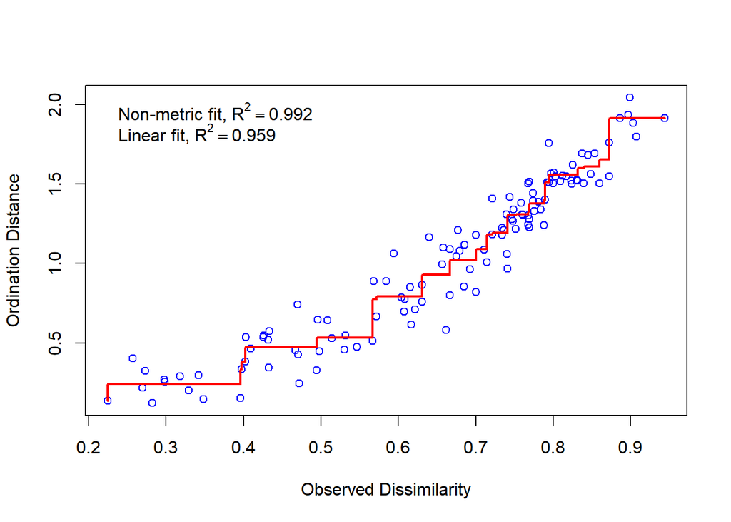

```r
stressplot(nmds.spider.pa)
```

```r
library(vegan)
```

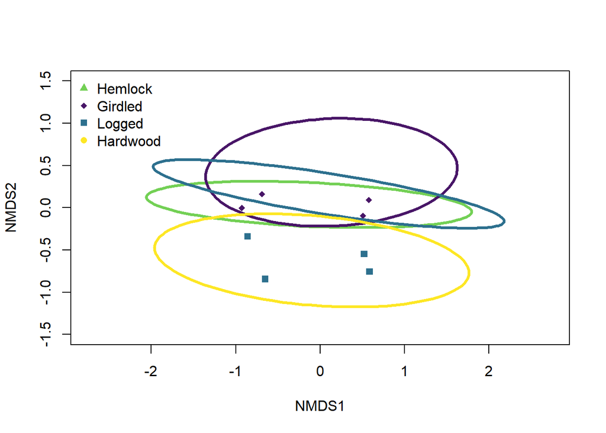

```r
ordiplot(nmds.spider.pa, display = "sites", type="n", xlim = c(-1.5, 1.5), ylim=c(-1.5, 1.5))
points(nmds.spider.pa, display = "sites",select= which(spider_cleaned_2$treatment=="HemlockControl"),pch=17,cex=1, col="#73D055FF")
points(nmds.spider.pa, display = "sites",select= which(spider_cleaned_2$treatment=="Girdled"),pch = 18,cex=1,col="#481567FF")
points(nmds.spider.pa, display = "sites",select= which(spider_cleaned_2$treatment=="Logged"),pch=15,cex=1,col="#2D708EFF")
points(nmds.spider.pa, disp = "sites",select= which(spider_cleaned_2$treatment=="HardwoodControl"),pch=16,cex=1, col="#FDE725FF")
ordiellipse(nmds.spider.pa,spider_cleaned_2$treatment,draw="lines",col=c("#73D055FF","#481567FF","#2D708EFF","#FDE725FF"), lwd=3,kind="sd",conf=0.95,label=FALSE)
legend("topleft",legend= c("Hemlock","Girdled","Logged","Hardwood"), pch=c(17,18,15,16),cex=1,bty="n",col=c("#73D055FF","#481567FF","#2D708EFF","#FDE725FF"))
```

## 4. Run a permutational multivariate analysis of variance (PERMANOVA) using adonis2(). Model the bray-curtis distance matrix as a function of treatment. Provide the PERMANOVA output.

```r
adonis2(dis.matrix.pa~spider1$treatment, permutations=999)
```

```
## Permutation test for adonis under reduced model
## Permutation: free
## Number of permutations: 999
##
## adonis2(formula = dis.matrix.pa ~ spider1$treatment, permutations = 999)
##          Df SumOfSqs      R2      F Pr(>F)
## Model     3   0.9211 0.26771 1.4623  0.159
## Residual 12   2.5196 0.73229
## Total    15   3.4407 1.00000
```

```r
library(pairwiseAdonis)
pairwise.adonis(dis.matrix.pa, spider1$treatment)
```

```
##                 pairs Df  SumsOfSqs   F.Model         R2 p.value p.adjusted sig
## 1   Logged vs Girdled  1 0.29367973 1.3319950 0.18166884   0.365      1.000
## 2   Logged vs Hemlock  1 0.47633776 2.1553416 0.26428588   0.058      0.348
## 3  Logged vs Hardwood  1 0.49814502 2.3928361 0.28510459   0.044      0.264
## 4  Girdled vs Hemlock  1 0.08785326 0.4148971 0.06467712   0.570      1.000
## 5 Girdled vs Hardwood  1 0.22740760 1.1431793 0.16003788   0.372      1.000
## 6 Hemlock vs Hardwood  1 0.25875632 1.2973633 0.17778522   0.347      1.000
```

## 5. Interpret the output (using the figure and PERMANOVA results).

Overall, however, all the treatment groups contribute small portion of total data variation, and there are no statistically clear results.

## 6. Now, some data wrangling for the understory herb data. Change the data set from long format to wide format using species as the taxonomic resolution (i.e., each column should be a plant species). Be sure that the new data frame includes the predictor variables year, block, trt, plot, and subplot. Then, subset the data by year 2008, so it aligns with the spider data. Lastly, double check that the number of samples per plot aligns between the spider and plant data sets. Each plot should have 10 samples (indicated as replicates or subplots)

```r
library(dplyr)
herb.matrix <- dcast(herb, year+block+plot+trt ~ species, mean, value.var="cover", fill=0)
herb.matrix <- herb.matrix %>% rename(treatment = trt)
View(herb.matrix)
```

```r
herb.matrix$year<-as.factor(herb.matrix$year)
herb.matrix$block<-as.factor(herb.matrix$block)
herb.matrix$plot<-as.factor(herb.matrix$plot)
herb.matrix$treatment<-as.factor(herb.matrix$treatment)
```

```r
levels(herb.matrix$year)
```

```
##  [1] "2003" "2004" "2005" "2006" "2007" "2008" "2009" "2010" "2011" "2012"
## [11] "2013" "2014" "2015" "2016" "2017" "2018" "2019" "2020" "2021" "2022"
## [21] "2023"
```

```r
herb.matrix <- herb.matrix %>% filter(year=="2008") %>% droplevels()
herb.matrix <- herb.matrix[, colSums(herb.matrix !=0)>0]
View(herb.matrix)
```

## 7. Run a detrended correspondence analysis (DCA) to determine the most appropriate constrained model for these data. Provide the output. Use the original data set with abundances.

```r
DCA <- decorana(spider_cleaned_2[,6:56])
DCA
```

```
##
## Call:
## decorana(veg = spider_cleaned_2[, 6:56])
##
## Detrended correspondence analysis with 26 segments.
## Rescaling of axes with 4 iterations.
## Total inertia (scaled Chi-square): 1.7996
##
##                        DCA1   DCA2    DCA3    DCA4
## Eigenvalues          0.5277 0.3071 0.14496 0.10451
## Additive Eigenvalues 0.5277 0.3024 0.14426 0.07513
## Decorana values      0.5472 0.1858 0.07301 0.03454
## Axis lengths         2.6433 2.5389 1.39815 1.27517
```

## 8. Run the appropriate model (RDA or CCA). Provide a figure.

```r
spider.matrix.rda <- dcast(spiders, year+ block + plot + treatment ~ genus, sum,value.var="abundance",na.rm=TRUE)
View(spider.matrix.rda)

spider.matrix.rda$year<-as.factor(spider.matrix.rda$year)
spider.matrix.rda$block<-as.factor(spider.matrix.rda$block)
spider.matrix.rda$plot<-as.factor(spider.matrix.rda$plot)
spider.matrix.rda$treatment<-as.factor(spider.matrix.rda$treatment)

spider.matrix.rda <- spider.matrix.rda %>% select(-contains("imm"), -c(LinytoID, LinyToID, unk_toID))

View(spider.matrix.rda)
```

```r
library(vegan)
spider.rda <- rda(spider.matrix.rda[,5:55] ~ ., herb.matrix[,5:41])
```

```
##
## Some constraints or conditions were aliased because they were redundant. This
## can happen if terms are linearly dependent (collinear): 'corcor', 'denobs',
## 'epirep', 'erehie', 'eurdiv', 'gootes', 'hamvir', 'hupluc', 'ilever', 'lysbor',
## 'lysqua', 'maican', 'medvir', 'mitrep', 'monuni', 'oclacu', 'osmcin', 'parnov',
## 'parqui', 'polacr', 'pyrmin', 'ruball', 'rubhis', 'rubida', 'uvuses', 'vacang',
## 'vaccor', 'vacsp', 'vibnud', 'ztot.cover'
```

```
##
## The model is overfitted with no unconstrained (residual) component
```

```r
summary(spider.rda)
```

```
##
## Call:
## rda(formula = spider.matrix.rda[, 5:55] ~ arahis + aranud + berthu +      carpen + carsp + corcor + denobs + denpun + drysp + epirep +      erehie + eurdiv + gootes + hamvir + hupluc + ilever + lysbor +      lysqua + maican + medvir + mitrep + monuni + oclacu + osmcin +      parnov + parqui + pol…
##
## Partitioning of variance:
##               Inertia Proportion
## Total            4249          1
## Constrained      4249          1
## Unconstrained       0          0
##
## Eigenvalues, and their contribution to the variance
##
## Importance of components:
##                            RDA1      RDA2     RDA3      RDA4      RDA5     RDA6
## Eigenvalue            1705.6156 1170.9117 833.2808 247.16656 196.69548 71.61410
## Proportion Explained     0.4014    0.2756   0.1961   0.05817   0.04629  0.01685
## Cumulative Proportion    0.4014    0.6769   0.8730   0.93121   0.97750  0.99436
##                            RDA7
## Eigenvalue            23.983549
## Proportion Explained   0.005644
## Cumulative Proportion  1.000000
##
## Accumulated constrained eigenvalues
## Importance of components:
##                            RDA1      RDA2     RDA3      RDA4      RDA5     RDA6
## Eigenvalue            1705.6156 1170.9117 833.2808 247.16656 196.69548 71.61410
## Proportion Explained     0.4014    0.2756   0.1961   0.05817   0.04629  0.01685
## Cumulative Proportion    0.4014    0.6769   0.8730   0.93121   0.97750  0.99436
##                            RDA7
## Eigenvalue            23.983549
## Proportion Explained   0.005644
## Cumulative Proportion  1.000000
```

```r
mod0.rda <- rda(spider.matrix.rda[,5:55] ~ 1, herb.matrix[,5:41])
spider.rda.red <- ordistep(mod0.rda, scope = formula(spider.rda), direction = "both", permutations = how(nperm = 199))
```

```
##
## Start: spider.matrix.rda[, 5:55] ~ 1
##
##              Df    AIC      F Pr(>F)
## + maican      1 66.308 3.2458  0.010 **
## + monuni      1 66.236 3.3303  0.015 *
## + vaccor      1 66.345 3.2039  0.025 *
## + carpen      1 66.699 2.8054  0.035 *
## + denobs      1 66.807 2.6870  0.035 *
## + ztot.cover  1 67.399 2.0672  0.040 *
## + aranud      1 66.816 2.6779  0.045 *
## + denpun      1 67.260 2.2087  0.055 .
## + uvuses      1 66.509 3.0170  0.095 .
## + arahis      1 67.148 2.3250  0.095 .
## + medvir      1 66.509 3.0170  0.120
## + ruball      1 67.816 1.6574  0.165
## + lysbor      1 67.893 1.5849  0.175
## + hupluc      1 67.781 1.6911  0.180
## + corcor      1 67.949 1.5320  0.210
## + hamvir      1 67.949 1.5320  0.215
## + parqui      1 67.949 1.5320  0.215
## + vacang      1 68.102 1.3890  0.245
## + eurdiv      1 67.949 1.5320  0.250
## + vibnud      1 67.949 1.5320  0.255
## + oclacu      1 67.949 1.5320  0.295
## + carsp       1 68.431 1.0913  0.330
## + rubida      1 68.434 1.0883  0.375
## + rubhis      1 68.419 1.1014  0.385
## + lysqua      1 68.553 0.9840  0.445
## + vacsp       1 68.553 0.9840  0.490
## + mitrep      1 68.784 0.7848  0.590
## + gootes      1 68.932 0.6609  0.630
## + erehie      1 68.932 0.6609  0.660
## + epirep      1 69.131 0.4971  0.740
## + berthu      1 69.131 0.4971  0.755
## + pyrmin      1 69.131 0.4971  0.765
## + ilever      1 69.131 0.4971  0.775
## + osmcin      1 69.131 0.4971  0.780
## + parnov      1 69.164 0.4704  0.875
## + drysp       1 69.366 0.3089  0.965
```

[output cut: 177 more lines]

```
## + oclacu  1 59.828 0.9323  0.560
## + carpen  1 59.828 0.9323  0.565
## + corcor  1 59.828 0.9323  0.565
## + pyrmin  1 59.828 0.9323  0.570
## + osmcin  1 59.828 0.9323  0.570
## + parqui  1 59.828 0.9323  0.575
## + vibnud  1 59.828 0.9323  0.590
## + medvir  1 59.828 0.9323  0.595
## + uvuses  1 59.828 0.9323  0.595
## + eurdiv  1 59.828 0.9323  0.600
## + berthu  1 59.828 0.9323  0.615
## + hamvir  1 59.828 0.9323  0.620
## + hupluc  1 60.382 0.6693  0.675
## + polacr  1 60.470 0.6294  0.700
## + mitrep  1 60.890 0.4438  0.700
```

```r
summary(spider.rda.red)
```

```
##
## Call:
## rda(formula = spider.matrix.rda[, 5:55] ~ maican + ztot.cover +      vaccor, data = herb.matrix[, 5:41])
##
## Partitioning of variance:
##               Inertia Proportion
## Total          4249.3     1.0000
## Constrained    3489.7     0.8213
## Unconstrained   759.5     0.1787
##
## Eigenvalues, and their contribution to the variance
##
## Importance of components:
##                            RDA1      RDA2     RDA3       PC1       PC2
## Eigenvalue            1612.2065 1128.7755 748.7652 315.33485 262.85001
## Proportion Explained     0.3794    0.2656   0.1762   0.07421   0.06186
## Cumulative Proportion    0.3794    0.6450   0.8213   0.89547   0.95733
##                             PC3      PC4
## Eigenvalue            126.17995 55.15585
## Proportion Explained    0.02969  0.01298
## Cumulative Proportion   0.98702  1.00000
##
## Accumulated constrained eigenvalues
## Importance of components:
##                           RDA1      RDA2     RDA3
## Eigenvalue            1612.207 1128.7755 748.7652
## Proportion Explained     0.462    0.3235   0.2146
## Cumulative Proportion    0.462    0.7854   1.0000
```

```r
anova(spider.rda.red, by = 'axis')
```

```
## Permutation test for rda under reduced model
## Forward tests for axes
## Permutation: free
## Number of permutations: 999
##
## Model: rda(formula = spider.matrix.rda[, 5:55] ~ maican + ztot.cover + vaccor, data = herb.matrix[, 5:41])
##          Df Variance      F Pr(>F)
## RDA1      1  1612.21 8.4907  0.001 ***
## RDA2      1  1128.78 5.9447  0.002 **
## RDA3      1   748.77 3.9434  0.033 *
## Residual  4   759.52
## ---
## Signif. codes:  0 '***' 0.001 '**' 0.01 '*' 0.05 '.' 0.1 ' ' 1
```

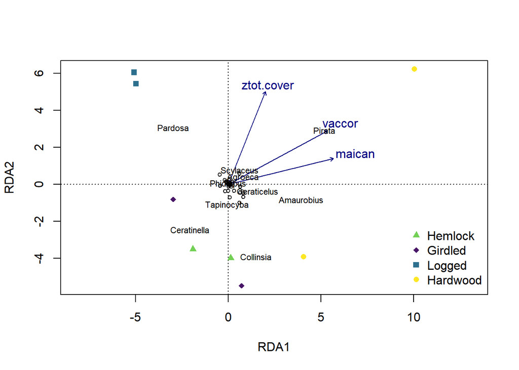

```r
ordiplot(spider.rda.red, display = c('si', 'cn'), type = 'n')
points(spider.rda.red, dis = "sites", select = which(herb.matrix$treatment=="hemlock"), pch = 17, cex = 1, col = "#73D055FF")
points(spider.rda.red, dis = "sites", select = which(herb.matrix$treatment=="girdled"), pch = 18, cex = 1, col = "#481567FF")
points(spider.rda.red, dis = "sites", select = which(herb.matrix$treatment=="logged"), pch = 15, cex = 1, col = "#2D708EFF")
points(spider.rda.red, dis = "sites", select = which(herb.matrix$treatment=="hardwood"), pch = 16, cex = 1, col = "#FDE725FF")
text(spider.rda.red, display = 'cn', col = 'navy', cex = 1)
orditorp(spider.rda.red, display = 'sp')
legend("bottomright", legend = c("Hemlock", "Girdled", "Logged", "Hardwood"),pch = c(17, 18, 15, 16), cex = 1, bty = "n", col = c("#73D055FF", "#481567FF", "#2D708EFF", "#FDE725FF"))
```